# How to predict with missing values in R?

Katarzyna Woźnica

```r
library(OpenML)
library(DT)
library(mice)
library(missForest)
library(VIM)
library(softImpute)
library(ggplot2)
library("factoextra")
library("likert")
```

# 1 Example of imputation in R

## 1.1 Get your data

As an example of incomplete data, we use real-world from OpenML. We download this data directly from the website using the package `OpenML`. We select binary classification task [ipums_la_99-small](https://www.openml.org/d/1018). It has $8844$ instances and $57$ features numeric and categorical.

An exemplary sample of data is presented below.

```r
list_all_openml_dataset <- listOMLDataSets()

openml_id <-    1018L
data_name <- list_all_openml_dataset[list_all_openml_dataset[,'data.id'] == openml_id,'name']

dataset_openml <- getOMLDataSet(data.id = openml_id)
dataset_raw <- dataset_openml$data
target_column <- dataset_openml$target.features


#Removing year column evary value the same

dataset <- dataset_raw[,-1]
datatable(head(data.frame(dataset)))
```

|  | gq | gqtypeg | farm | ownershg | value | rent | ftotinc | nfams | ncouples | nmothers | nfathers | momloc | stepmom | momrule | poploc | steppop | poprule | sploc | sprule | famsize | nchild | nchlt5 | famunit | eldch | yngch | nsibs | relateg | age | sex | … |
| --- | --- | --- | --- | --- | --- | --- | --- | --- | --- | --- | --- | --- | --- | --- | --- | --- | --- | --- | --- | --- | --- | --- | --- | --- | --- | --- | --- | --- | --- | --- |
| 0 | HH_in_1970_definition_but_sampled_as_larger_unit | NA_(household) | Non-Farm | Rented | 999999 | 412 | 23000 | 2 | 0 | 1 | 1 | 0 | 0 | 0 | 1 | 0 | 1 | 0 | 0 | 7 | 0 | 0 | 1 | 99 | 99 | 1 | Child | 14 | Female | … |
| 1 | HH_in_1970_definition_but_sampled_as_larger_unit | NA_(household) | Non-Farm | Owned_or_being_bought_(loan) | 162500 | 0 | 38008 | 2 | 0 | 0 | 0 | 0 | 0 | 0 | 0 | 0 | 0 | 0 | 0 | 1 | 0 | 0 | 1 | 99 | 99 | 0 | Head_Householder | 25 | Male | … |
| 2 | HH_in_1970_definition_but_sampled_as_larger_unit | NA_(household) | Non-Farm | Rented | 999999 | 675 | 0 | 1 | 0 | 1 | 0 | 1 | 0 | 1 | 0 | 0 | 0 | 0 | 0 | 2 | 0 | 0 | 1 | 99 | 99 | 0 | Child | 5 | Female | … |
| 3 | HH_in_1970_definition_but_sampled_as_larger_unit | NA_(household) | Non-Farm | Rented | 999999 | 725 | 23008 | 2 | 1 | 1 | 1 | 1 | 0 | 1 | 2 | 0 | 1 | 0 | 0 | 5 | 0 | 0 | 1 | 99 | 99 | 2 | Child | 2 | Male | … |
| 4 | HH_in_1970_definition_but_sampled_as_larger_unit | NA_(household) | Non-Farm | Owned_or_being_bought_(loan) | 400000 | 0 | 104000 | 1 | 1 | 1 | 1 | 2 | 0 | 1 | 1 | 0 | 1 | 0 | 0 | 5 | 0 | 0 | 1 | 99 | 99 | 2 | Child | 10 | Male | … |
| 5 | HH_in_1970_definition_but_sampled_as_larger_unit | NA_(household) | Non-Farm | Owned_or_being_bought_(loan) | 85000 | 0 | 17000 | 1 | 1 | 0 | 0 | 0 | 0 | 0 | 0 | 0 | 0 | 1 | 1 | 2 | 0 | 0 | 1 | 99 | 99 | 0 | Spouse | 85 | Female | … |

### 1.1.1 Train/test split

To fit the classification model and, next, evaluate it, we split this data into train and test data.

```r
train_percent_of_data <- 0.8

 set.seed(123)
 no_instances <- nrow(dataset)

 train_index <- sort(sample(1:no_instances, floor(train_percent_of_data * no_instances)))



  dataset_train_test_list<- list(data_train  = dataset[train_index,],
                            data_test  = dataset[-train_index,],
                            target_name = target_column)
```

## 1.2 Imputation functions

Available imputation methods have diverse interfaces. Below there are examples of usage of popular imputation methods: softImpute, mice, missForest and knn and hotdeck imputation from VIM package. There are also the implementation of random imputation and mean/mode imputation.

If you would like to use unified interface for these imputation methods we recommend to use our [NADIA package](https://cran.r-project.org/web/packages/NADIA/index.html).

### 1.2.1 Random imputation

```r
random_replace_in_vector <- function(x){
  x[is.na(x)] <- sample(unique(na.omit(x)), sum(is.na(x)), replace = TRUE)
  return(x)
}
```

### 1.2.2 Mean imputation

```r
imputation_mode_mean <- function(df){
  # browser()
  Mode <- function(x) {
    ux <- unique(na.omit(x))
    ux[which.max(tabulate(match(x, ux)))]
  }

  for (i in 1L:length(df)){
    if (sum(is.na(df[,i])) > 0){
      if (mode(df[,i]) == 'character' | is.factor(df[,i])){
        to_imp <- Mode(df[,i])
        df[,i][is.na(df[,i])] <- to_imp
      }
      else{
        to_imp <- mean(df[,i], na.rm = TRUE)
        df[,i][is.na(df[,i])] <- to_imp
      }
    }
  }

  return(df)
}
```

### 1.2.3 K nearest neighbours

```r
imputation_fun_vim <- function(df){
  no_columns <- length(df)
  imputed <- kNN(df)
  imputed <- imputed[,1:no_columns]
  return(imputed)
}
```

### 1.2.4 VIM hotdeck

```r
imputation_fun_vim_hotdeck <- function(df){
  no_columns <- length(df)
  imputed <- hotdeck(df)
  imputed <- imputed[,1:no_columns]
  return(imputed)
}
```

### 1.2.5 missForest

```r
imputation_fun_missForest <- function(df){
  return(missForest(df)$ximp)
}
```

### 1.2.6 softimpute

This method works only for numeric features. For nominal columns, we perform imputations with mode values.

```r
imputation_softimpute <- function(data){
  # browser()
  type_of_data <- sapply(data, class)
  factor_columns <- colnames(data)[type_of_data=='factor']
  cat_data <- data[,factor_columns]
  cat_data_imputed <- imputation_mode_mean(cat_data)

  numeric_colnames <- setdiff(colnames(data), factor_columns)

  if(length(numeric_colnames)>0){
  numeric_data <- as.matrix(data[, numeric_colnames])

  imputer <- softImpute(numeric_data)



  numeric_data_imputed <- softImpute::complete(numeric_data, imputer)


  all_data_imputed <- cbind(cat_data_imputed, numeric_data_imputed)[,colnames(data)]
  }
  else{
    all_data_imputed <- cat_data_imputed[,colnames(data)]
  }
  all_data_imputed
}
```

### 1.2.7 mice

```r
imputation_fun_mice <- function(df){
  init <- mice(df, maxit=0, remove.collinear = FALSE, remove.constant = FALSE)
  meth <- init$method
  predM <- init$predictorMatrix
  imputed <- mice(df, method=meth, predictorMatrix=predM, m=5, nnet.MaxNWts = 5000, remove.collinear = FALSE, remove.constant = FALSE)
  completed <- mice::complete(imputed)
  return(completed)
}
```

## 1.3 Imputation of data

We want to perform imputation separately on the train and test data set, excluding the target variable (to avoid data leakage). Below we propose a function that automates this step for any imputation methods in which the argument is incomplete data and returns completed data frame.

```r
get_imputed_data <- function(data,   imputed_function){

  train <- data$data_train[, -c(which(colnames(data$data_train) ==data$target_name))]
  test <- data$data_test[, -c(which(colnames(data$data_test) ==data$target_name))]

  expr_time <- system.time({
    imputed_data <- lapply(list(train, test), imputed_function)

  })
  names(imputed_data) <- c('data_train', 'data_test')
  imputed_data$data_train <- cbind(imputed_data$data_train, data$data_train[, data$target_name] )
  imputed_data$data_test <- cbind(imputed_data$data_test, data$data_test[, data$target_name] )

  colnames(imputed_data$data_train)[ncol(imputed_data$data_train)] <- data$target_name
  colnames(imputed_data$data_test)[ncol(imputed_data$data_test)] <- data$target_name

  return(list(imputed_data = imputed_data,
              target_name = data$target_name,
              time = expr_time))


}
```

### 1.3.1 Example of use

```r
softimpute_complete_data_train_test_list <- get_imputed_data(data = dataset_train_test_list, imputed_function = imputation_softimpute)
datatable(head(softimpute_complete_data_train_test_list$imputed_data$data_train))
```

|  | gq | gqtypeg | farm | ownershg | value | rent | ftotinc | nfams | ncouples | nmothers | nfathers | momloc | stepmom | momrule | poploc | steppop | poprule | sploc | sprule | famsize | nchild | nchlt5 | famunit | eldch | yngch | nsibs | relateg | age | sex | … |
| --- | --- | --- | --- | --- | --- | --- | --- | --- | --- | --- | --- | --- | --- | --- | --- | --- | --- | --- | --- | --- | --- | --- | --- | --- | --- | --- | --- | --- | --- | --- |
| 0 | HH_in_1970_definition_but_sampled_as_larger_unit | NA_(household) | Non-Farm | Rented | 999999 | 412 | 23000 | 2 | 0 | 1 | 1 | 0 | 0 | 0 | 1 | 0 | 1 | 0 | 0 | 7 | 0 | 0 | 1 | 99 | 99 | 1 | Child | 14 | Female | … |
| 1 | HH_in_1970_definition_but_sampled_as_larger_unit | NA_(household) | Non-Farm | Owned_or_being_bought_(loan) | 162500 | 0 | 38008 | 2 | 0 | 0 | 0 | 0 | 0 | 0 | 0 | 0 | 0 | 0 | 0 | 1 | 0 | 0 | 1 | 99 | 99 | 0 | Head_Householder | 25 | Male | … |
| 2 | HH_in_1970_definition_but_sampled_as_larger_unit | NA_(household) | Non-Farm | Rented | 999999 | 675 | 0 | 1 | 0 | 1 | 0 | 1 | 0 | 1 | 0 | 0 | 0 | 0 | 0 | 2 | 0 | 0 | 1 | 99 | 99 | 0 | Child | 5 | Female | … |
| 3 | HH_in_1970_definition_but_sampled_as_larger_unit | NA_(household) | Non-Farm | Rented | 999999 | 725 | 23008 | 2 | 1 | 1 | 1 | 1 | 0 | 1 | 2 | 0 | 1 | 0 | 0 | 5 | 0 | 0 | 1 | 99 | 99 | 2 | Child | 2 | Male | … |
| 4 | HH_in_1970_definition_but_sampled_as_larger_unit | NA_(household) | Non-Farm | Owned_or_being_bought_(loan) | 400000 | 0 | 104000 | 1 | 1 | 1 | 1 | 2 | 0 | 1 | 1 | 0 | 1 | 0 | 0 | 5 | 0 | 0 | 1 | 99 | 99 | 2 | Child | 10 | Male | … |
| 5 | HH_in_1970_definition_but_sampled_as_larger_unit | NA_(household) | Non-Farm | Owned_or_being_bought_(loan) | 85000 | 0 | 17000 | 1 | 1 | 0 | 0 | 0 | 0 | 0 | 0 | 0 | 0 | 1 | 1 | 2 | 0 | 0 | 1 | 99 | 99 | 0 | Spouse | 85 | Female | … |

# 2 Benchmark of imputation methods

To compare imputation methods and their impact on the predictive quality of machine learning classification algorithm we perform a benchmark. We select 7 imputation methods: random, mean, mice, softImpute, missForest and kknn and hotdeck from VIM package. We use the implemented function from the first part of this notebook.

We test these imputation methods on selected real-world data sets. Each data frame is divided into train and test part and every imputation algorithm is performed separately on them.

Next, 5 types of machine learning algorithms are fitted on every imputed train data: glmnet, rpart, ranger implementation of random forest, kknn and xgboost. Every trained model is evaluated on the test part of the considered data set, completed using the same imputation as applied on train part. To evaluation, we use two measure of performance: AUC and F1.

AUC is kind of assessment of the separability of predictions. It is area under ROC Curve - true positive rate against false positive rate for a series of different thresholds for probability predictions. AUC measure lies between 0 and 1. For simplification, we may assume that the closer AUC to 1, the better model we have.

F1 measure is the harmonic mean of precision (the number of correctly identified positive results divided by the number of all positive results, including those not identified correctly) and recall (the number of correctly identified positive results divided by the number of all samples that should have been identified as positive). F1 takes values between 0 and 1.

## 2.1 Datasets summary

We select 13 datasets with at least one column with missing values from OpenML. There are binary classification tasks. In the table below we present a summary of basic information about considered tasks.

|  | Dataset(ID) | No. of obs. | % missing values | No. numeric features | No. numeric features with missings | No. factor features | No. factor features with missings |
| --- | --- | --- | --- | --- | --- | --- | --- |
| 1 | ipums_la_99-small (1018) | 8844 | 7% | 15 | 0 | 41 | 14 |
| 2 | adult (1590) | 48842 | 1% | 4 | 0 | 9 | 3 |
| 3 | eucalyptus (188) | 736 | 3.9% | 14 | 10 | 2 | 0 |
| 4 | dresses-sales (23381) | 500 | 14.7% | 1 | 1 | 12 | 9 |
| 5 | colic (27) | 368 | 16.3% | 5 | 5 | 15 | 13 |
| 6 | credit-approval (29) | 690 | 0.6% | 6 | 2 | 10 | 5 |
| 7 | sick (38) | 3772 | 2.2% | 6 | 6 | 22 | 1 |
| 8 | labor (4) | 57 | 33.6% | 8 | 8 | 9 | 8 |
| 9 | SpeedDating (40536) | 8378 | 1.8% | 59 | 58 | 64 | 3 |
| 10 | hepatitis (55) | 155 | 5.4% | 6 | 5 | 14 | 10 |

[output cut: 3 more lines]

## 2.2 Collected results

For every data set, imputation methods and machine learning algorithm we get 2 values of performance measure: F1 and AUC. So a total of 910 rows should be in the collected results. Unfortunately, some imputations fail on certain data sets.

```r
library("tidyr")

tab <- read.table("/home/kasia/Documents/PhDstudies/AutoImpute/EMMA/metrics_results//metrics_df.csv", sep = ",", header = TRUE)[,-1]
datatable(tab)
```

|  | dataset | imputation_method | model | metric | metric_value |
| --- | --- | --- | --- | --- | --- |
| 1 | openml_dataset_1018 | mean | classif.rpart | auc | 0.5 |
| 2 | openml_dataset_1018 | mean | classif.rpart | f1 | 0.967911318553092 |
| 3 | openml_dataset_1018 | mean | classif.glmnet | auc | 0.900720587429448 |
| 4 | openml_dataset_1018 | mean | classif.glmnet | f1 | 0.967855055523086 |
| 5 | openml_dataset_1018 | mean | classif.kknn | auc | 0.709948490328237 |
| 6 | openml_dataset_1018 | mean | classif.kknn | f1 | 0.961515689757253 |
| 7 | openml_dataset_1018 | mean | classif.ranger | auc | 0.901353498821853 |
| 8 | openml_dataset_1018 | mean | classif.ranger | f1 | 0.968402574605032 |
| 9 | openml_dataset_1018 | mean | classif.xgboost | auc | 0.89207353827607 |
| 10 | openml_dataset_1018 | mean | classif.xgboost | f1 | 0.965130023640662 |

[output cut: 830 more lines]

## 2.3 Scatterplot for raw data

There is a visualization of collected measures for every data set splitting with algorithm type.

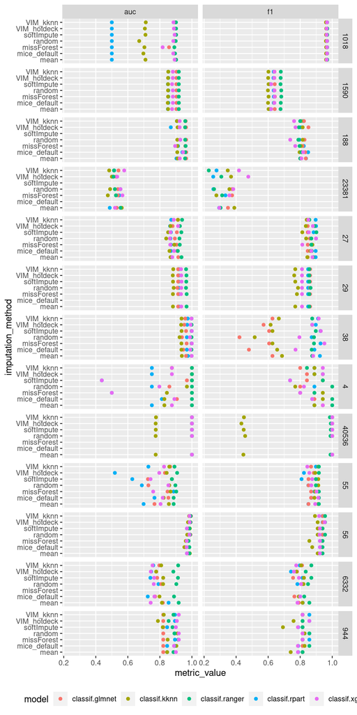

```r
tab %>%
  mutate(dataset = gsub('openml_dataset_','',dataset )) %>%
  ggplot( aes(imputation_method, metric_value, color = model)) +
  geom_point() +
  facet_grid(dataset~metric) +
  coord_flip() +
  theme(legend.position = "bottom")
```

As we see AUC and F1 are incomparable across data sets, so next to the comparison of values of metrics we create the ranking. For every task and every machine learning algorithms we rank imputation methods, scores can range from 1 to 7. The higher and better measure the lower rank obtain this imputation technique. Methods which did not work on specific task get the lowest score (7).

```r
# fill the NA data
tab %>%
  tidyr::complete(dataset, model, imputation_method, metric, fill = list(metric_value = 0)) ->
  tab_complete

# calculate ranks
tab_complete %>%
  group_by(metric, model, dataset) %>%
  mutate(metric_rank = rank(-metric_value, ties.method = "max")) -> tab_rank

tab_complete %>%
  filter(metric == "f1") %>%
  pivot_wider(id_cols = c("dataset", "model"),
            names_from = "imputation_method",
            values_from = "metric_value") -> tmp
```

## 2.4 Does exist the best universal imputation method?

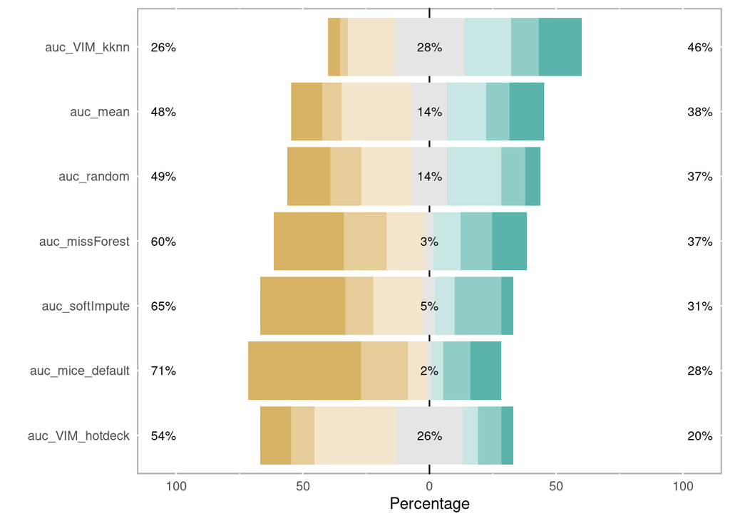

```r
library("tidyr")

# change order
tab_rank$metric_rank_likert <- factor(8-tab_rank$metric_rank)
pivot_wider(tab_rank,
            id_cols = c("dataset", "model"),
            names_from = c("metric", "imputation_method"),
            values_from = "metric_rank_likert") -> full_tab

p <- likert(as.data.frame(full_tab[,c(3,5,7,9,11,13,15)]))
plot(p,  legend.position = "none")
```

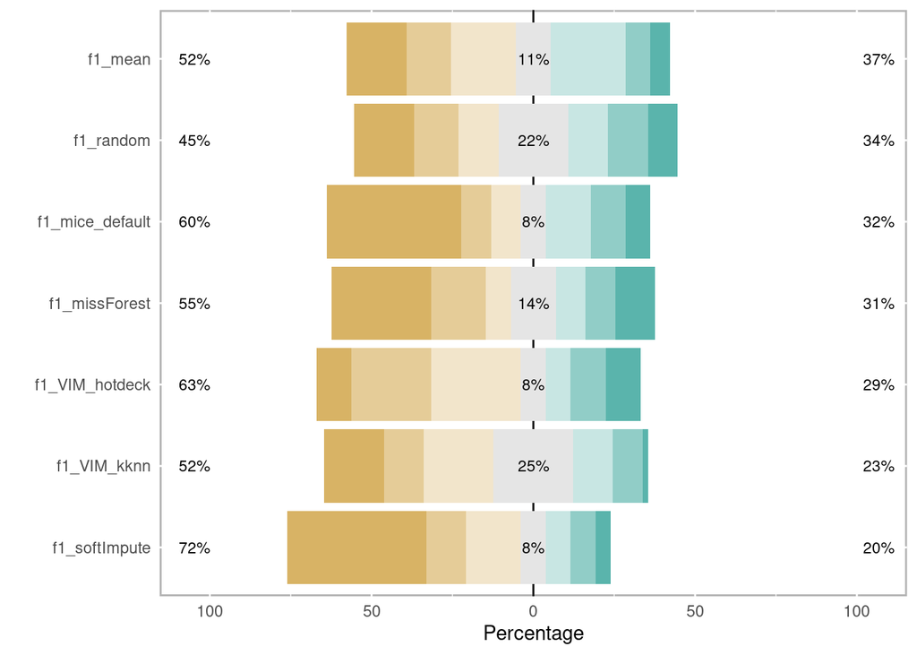

```r
p <- likert(as.data.frame(full_tab[,1+c(3,5,7,9,11,13,15)]))
plot(p,  legend.position = "none")
```

## 2.5 Do simple methods work effectively on similar tasks and ML algorithms?

We present the percentage of covered best results in rankings of F1 and AUC measure by single imputation methods and all pairs of them. The OX axis shows how often the indicated imputation method has the best results measured by the AUC. The OY axis shows how often the indicated imputation method has the best results measured by F1. The points marked A+B refer to the better of the two indicated methods (parallel max).

Combinations of two methods are able to cover above $50\%$ of best results. For F1 measure optimal pair is *missForest* and *random*. For AUC this is *mean* and *VIM_kknn* imputation.

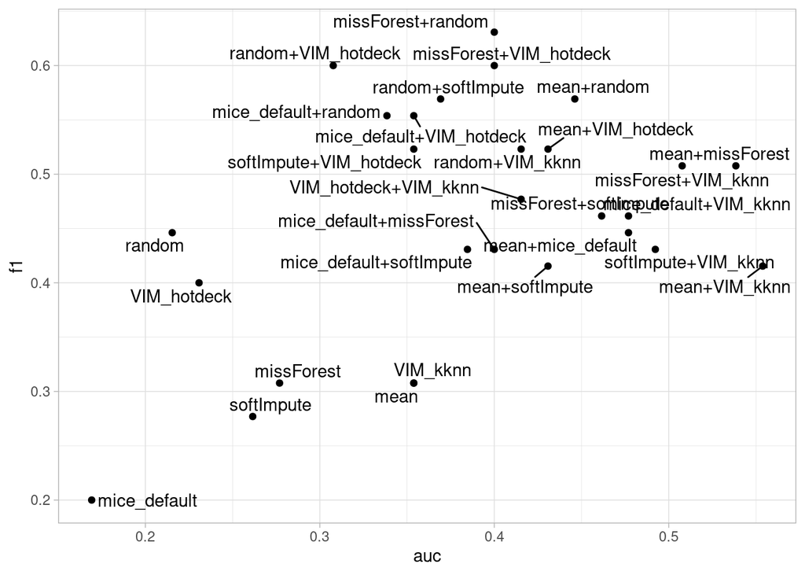

## 2.6 What are the interactions between ML algorithms and imputation methods?

Deeper insight into interaction of imputation and classifiers gives principal component analysis (PCA) performed on averaged rankings. The first PCA coordinate positively correlates with averaged ranking and the second coordinate reveals model preferences.

```r
tab_rank %>%
  filter(metric == "f1") %>%
  group_by(imputation_method, model) %>%
  summarise(avg_metric_rank = mean(as.numeric(as.character(metric_rank)))) %>%
  pivot_wider(id_cols = "imputation_method",
            names_from = "model",
            values_from = "avg_metric_rank") -> avg_full_tab
```

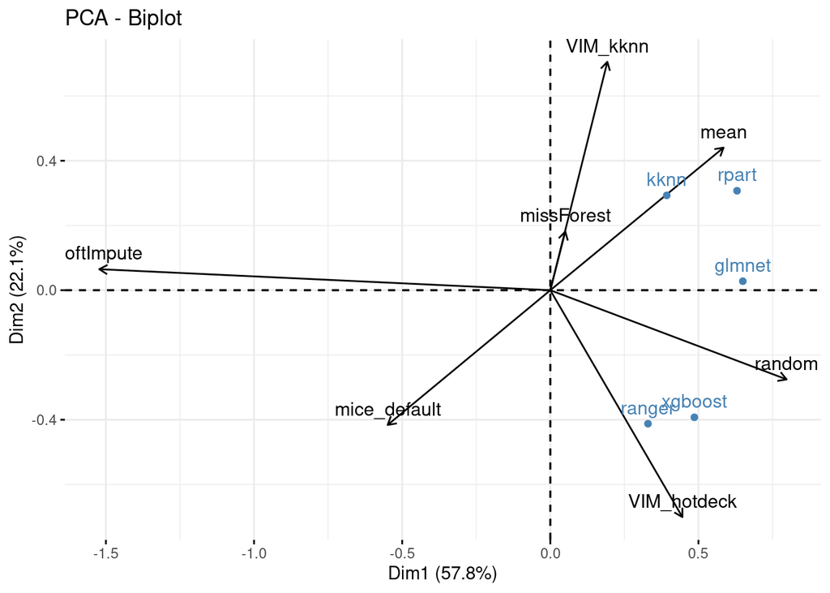

```r
avg_full_tab <- as.data.frame(avg_full_tab)
rownames(avg_full_tab) <- avg_full_tab[,1]
colnames(avg_full_tab) <- substr(colnames(avg_full_tab), 9, 100)

fit <- princomp(4 - avg_full_tab[,-1])
pl <- fviz_pca_biplot(fit,  geom = c("arrow", "text"), geom.var = c("point","text"))
pl
```

```r
tab_rank %>%
  filter(metric == "auc") %>%
  group_by(imputation_method, model) %>%
  summarise(avg_metric_rank = mean(as.numeric(as.character(metric_rank)))) %>%
  pivot_wider(id_cols = "imputation_method",
            names_from = "model",
            values_from = "avg_metric_rank") -> avg_full_tab
```

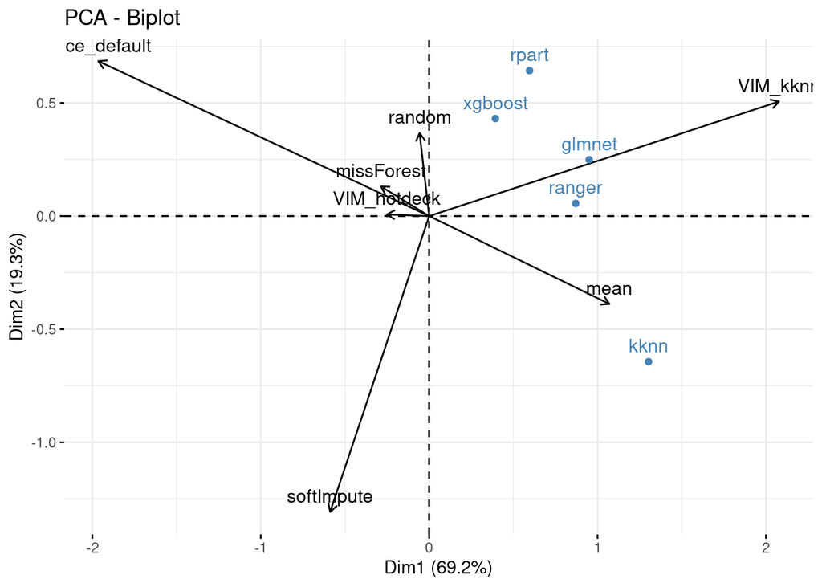

```r
avg_full_tab <- as.data.frame(avg_full_tab)
rownames(avg_full_tab) <- avg_full_tab[,1]
colnames(avg_full_tab) <- substr(colnames(avg_full_tab), 9, 100)

fit <- princomp(4 - avg_full_tab[,-1])
pl <- fviz_pca_biplot(fit,  geom = c("arrow", "text"), geom.var = c("point","text"))
pl
```

# 3 NADIA package

If you want to test different imputation method in predictive modeling we recommend to install the [NADIA package](https://cran.r-project.org/web/packages/NADIA/index.html). In addition to unified interface, this package provides advanced imputation methods as operation for mlr3 pipelines and adjust some of them to use in the out-of-the-box approach. So far, NADIA include imputation methods from mice, Amelia, missMDA, VIM, SoftImpute, MissRanger and MissForest.

More details you can find [here](https://medium.com/responsibleml/imputing-missing-data-with-emma-ed4cbc27510c) and [here](https://medium.com/responsibleml/missing-data-imputation-in-machine-learning-pipelines-214ef302889e)